# Leveraging a rolling cross-section design in panel studies to investigate police legitimacy

Monica Gerber and Cristóbal Moya

London School of Economics and Political Science

May 22, 2023

## The Study

- Police legitimacy

## The rolling cross-section design (RCS)

- **Cross-section**: data obtained at a specific point in time
  - Limited to correlational research
- Causal inference needs to consider time as a factor (Kenski et al., 2010)
- RCS distributes interviewing within a cross-section in a controlled (**random**) way over time (Johnston & Brady 2002; Kenski et al., 2010)
  - Total sample is divided into multiple **replicates** (smaller random sample)
  - Replicates are assigned to be interviewed at different intervals of times

## The rolling cross-section design (RCS)

### A little bit of history 1

- RCS design first introduced in the 1984 American National Election Study
  - Capture campaign effects

## The rolling cross-section design (RCS)

### Example 1

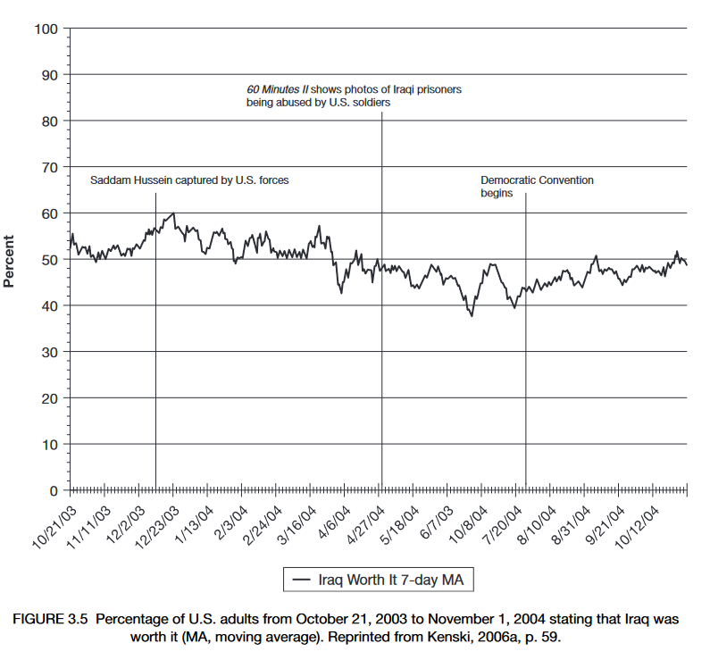

## The rolling cross-section design (RCS)

### Example 2

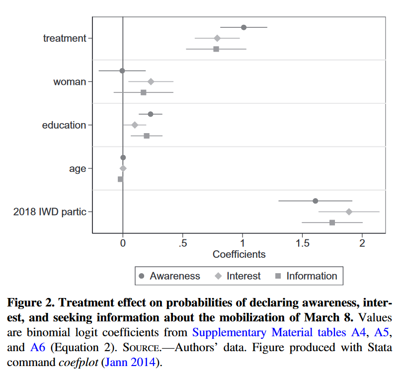

Figure from [Jiménez-Sánchez et al., 2022](https://allisonhorst.com)

## The rolling cross-section design (RCS)

### An example

“The data collected at the beginning of the survey should be used with caution as they will contain a” (Kenski et al., 2010, p. 59) (pdf)

“higher percentage of first-call attempts than data collected after the first round of subsamples released into the field have been exhausted.” (Kenski et al., 2010, p. 60) (pdf)

“The number of random subsamples of telephone numbers released into the field at each time interval is at the discretion of the researcher and will depend on the sample size goals and response rates achieved.” (Kenski et al., 2010, p. 60) (pdf)

“When a period of time is of particular interest to the researcher, the number of replicates released can be increased to enhance the sample’s power and thus ability to capture campaign effects.” (Kenski et al., 2010, p. 60) (pdf)

“A final element of the RCS approach is that all subsamples of telephone numbers must be treated in the same manner when released into the field. To ensure that each replicate is treated the same way, a research team should construct a consistent schedule of callbacks for all numbers.” (Kenski et al., 2010, p. 60) (pdf)

“Each telephone number should be given the same opportunity for completion as every other telephone number in the study.” (Kenski et al., 2010, p. 60) (pdf)

“Repeated Cross-Section Designs” (Kenski et al., 2010, p. 61) (pdf)

“In repeated cross-section studies, samples of the same population are gathered at two or more time points. Each sample (or cross-section) contains an independent set of respondents.” (Kenski et al., 2010, p. 61) (pdf)

“the repeated cross-section design “does not specify how far apart in time the waves of cross-sections should be conducted”” (Kenski et al., 2010, p. 61) (pdf)

“the cross-sections will often take place around key campaign events.” (Kenski et al., 2010, p. 61) (pdf)

““the goal is to determine whether a population has changed over time”” (Kenski et al., 2010, p. 61) (pdf)

“determine if a change has taken place in sample responses when the two or more time periods are compared.” (Kenski et al., 2010, p. 61) (pdf)

“may fail to capture unexpected events” (Kenski et al., 2010, p. 61) (pdf)

“Because the data are not necessarily released in a controlled way within a given cross-section, they cannot be used to examine changes that may have occurred within the timeframe in which the cross-section was conducted. The RCS design, however, can capture unexpected events because of the controlled way in which numbers are released into the field.” (Kenski et al., 2010, p. 61) (pdf)

“tracking polls” (Kenski et al., 2010, p. 61) (pdf)

“repeated cross-section design or the RCS design, depending on how the researchers release the sample to the field.” (Kenski et al., 2010, p. 61) (pdf)

“The potential problem is that daily sample sizes could contain different proportions of first-call attempts, second-call attempts, and so on if the sampling release has not been systematized so that the daily samples contain approximately the sample proportions of call attempts across time. Differences in call attempt proportions across time are only a problem if people who answer surveys after the first or second call attempt differ systematically from people who answer the survey after additional contact attempts; this is unfortunately not easy to determine in advance of conducting a study.” (Kenski et al., 2010, p. 61) (pdf)

“Panel Designs” (Kenski et al., 2010, p. 62) (pdf)

“the same individuals are interviewed at two or more points in time.” (Kenski et al., 2010, p. 62) (pdf)

“Because the same individuals are sampled at two or more points in time, panel designs are better than cross-sectional designs for establishing causal inferences (Schutt, 2006, p. 186). While the RCS and repeated cross-section designs can make inferences about groups, the panel design can make inferences about changes in behavior at the individual level.” (Kenski et al., 2010, p. 62) (pdf)

“How do we know that it was the convention that brought about the changes in people’s favorability ratings and not something else, such as advertising or favorable news coverage? How do we know that convention watchers were not already the kinds of people favorably disposed toward the candidate around whom the convention was centered? In this instance, a panel design would be able to address these counterarguments by offering empirical support that the individuals who reported watching the convention had actually changed their favorability ratings from Time 1 to Time 2.” (Kenski et al., 2010, p. 62) (pdf)

“the panel design has some limitations. First, the cost is too high to be able to realistically track the same respondents over the course of an entire campaign season, especially if the time interval between each wave of data collection is small. Second, panel mortality (or attrition) is often a problem.” (Kenski et al., 2010, p. 62) (pdf)

“As panel mortality increases, potentially more bias is introduced into the sample, and the less generalizable the study becomes.” (Kenski et al., 2010, p. 62) (pdf)

“interviewing the same individuals repeatedly may sensitize them to the concepts and methods of the study, and even allow for respondents to provide stock answers.” (Kenski et al., 2010, p. 62) (pdf)

“The National Annenberg Election Survey” (Kenski et al., 2010, p. 63) (pdf)

“replicates are released daily because an election campaign can be unexpectedly volatile. Consequently, it is more useful and revealing to have a smaller interval for the release of the replicates than it is to use longer intervals. As explained earlier, the smaller the interval for the release of the replicates, the more sensitive the data are to capturing campaign dynamics. A set schedule was established for callbacks to telephone numbers that were not answered on the first attempt.10” (Kenski et al., 2010, p. 63) (pdf)

“Between 50 and 300 interviews were completed daily, with a higher average number of interviews from July through November than the remaining months.” (Kenski et al., 2010, p. 64) (pdf)

“ADVANTAGES TO THE RCS DESIGN” (Kenski et al., 2010, p. 65) (pdf)

“it incorporates temporal heterogeneity into the methodology. Instead of treating time as a problem, the study design employs time as an opportunity for capturing effects.” (Kenski et al., 2010, p. 65) (pdf)

“Second, the RCS design is able to capture unexpected campaign events. Third, by tracking phenomena across time, scholars can potentially avoid misattributing outcomes to the wrong events. Fourth, data collected with the RCS can be segmented into different time periods for analysis. The design is flexible, allowing data to be utilized as single crosssections, repeated cross-section, or aggregated into time series. Fifth, if the RCS study is large, small subpopulations can be analyzed. Sixth, because respondents are interviewed once, there is minimal conditioning of study participant responses.” (Kenski et al., 2010, p. 65) (pdf)

“Incorporation of Temporal Heterogeneity” (Kenski et al., 2010, p. 65) (pdf)

“studying a population across an extended period of time,” (Kenski et al., 2010, p. 65) (pdf)

“A criticism of alternative methodologies is that temporal heterogeneity is an inherent flaw in their designs. The samples in a repeated crosssection study are taken over a specified period of time” (Kenski et al., 2010, p. 65) (pdf)

“The design assumes that no meaningful variation will take place within the sampling period of each collection.” (Kenski et al., 2010, p. 65) (pdf)

“the RCS design takes advantage of temporal heterogeneity by incorporating it as the driving force behind the method.” (Kenski et al., 2010, p. 65) (pdf)

“we could convert temporal heterogeneity into an object of study” (Brady & Johnston, 2006, p. 284).” (Kenski et al., 2010, p. 65) (pdf)

“the data can be placed into a timeseries format.” (Kenski et al., 2010, p. 65) (pdf)

“Capturing Unexpected Campaign Events” (Kenski et al., 2010, p. 66) (pdf)

“Most of the events that were referenced previously were not traditional campaign events that could have been predicted at the start of the campaign season.” (Kenski et al., 2010, p. 66) (pdf)

“Because the survey is continuously being administered in an RCS design, inferences can be made about the relationship between unexpected campaign events and public opinion.” (Kenski et al., 2010, p. 67) (pdf)

“Prevention of False Attribution” (Kenski et al., 2010, p. 67) (pdf)

“cross-section and panel designs focus on scheduled events, they can mistakenly attribute opinion change to the wrong event as unexpected events intervene between scheduled ones.” (Kenski et al., 2010, p. 67) (pdf)

“While a repeated cross-section study set around the debates would have captured the pre–post debate difference, it would not have been able to demonstrate that the decline took place well before the dates.” (Kenski et al., 2010, p. 68) (pdf)

“Flexibility in Breaking Down Data” (Kenski et al., 2010, p. 69) (pdf)

“The RCS design allows data to be sliced or aggregated in different ways. Smaller subsets of data can be taken from the larger dataset and used as a single cross-section or repeated cross-sections.” (Kenski et al., 2010, p. 69) (pdf)

“he data can also be used for time series purposes. To do so, the researcher need merely screen the data for the dates he or she wishes to use in the analyses and then aggregate responses to whatever unit of analysis needed for the time series.” (Kenski et al., 2010, p. 69) (pdf)

“Times series were created to show variables visually, and time series statistical techniques were used to uncover patterns not visible to the naked eye” (Kenski et al., 2010, p. 69) (pdf)

“Facility in Studying Populations and Subpopulations” (Kenski et al., 2010, p. 69) (pdf)

“Even though each replicate comprises a smaller number of interviews completed each day, the collective sample from the RCS can become substantial.” (Kenski et al., 2010, p. 69) (pdf)

“Because the NAES sample size is large, researchers can use the data to make generalizations about both large and small populations.” (Kenski et al., 2010, p. 69) (pdf)

“Minimal Conditioning” (Kenski et al., 2010, p. 70) (pdf)

“In an RCS design, replicates are never re-interviewed throughout the entire period of the study, although some RCS designs incorporate a panel design into them. For the initial RCS respondents, there is minimal conditioning (Brady & Johnston, 2006, p. 173). Each respondent is fresh to the interviewing process.” (Kenski et al., 2010, p. 70) (pdf) No indica ejemplos de estudios panel con rolling cross-section

“the RCS is not able to capture individual change and thus make generalizations about individual-level attitudes and behavior change. Second, because interviews are dispersed across a given time period, there can be difficulty studying individual days, because of issues pertaining to sample size. Third, researchers conducting time series analyses often use smoothing techniques to reveal dynamics visually; these smoothing techniques make assumptions that may not be able to disentangle “real” movement from sampling error. Fourth, because of the strict protocols employed to pieces of sample released to the field, response rates may potentially be lower than in other types of designs.” (Kenski et al., 2010, p. 70) (pdf)

“Inability to Capture Individual-Level Change” (Kenski et al., 2010, p. 70) (pdf)

“fresh respondents in each replicate released to the field. Individuals are never interviewed more than once.” (Kenski et al., 2010, p. 70) (pdf)

“A panel design is better suited for capturing individual-level changes (see Chapter 2, this volume). It is inappropriate to make generalizations about individuals from data that are group aggregated. Performing generalizations about individuals from group-level data constitutes the ecological fallacy:” (Kenski et al., 2010, p. 70) (pdf)

“The Difficulty of Studying Individual Days” (Kenski et al., 2010, p. 70) (pdf)

“Because the RCS is based on a relatively small number of interviews aggregated over a period of time, trying to analyze an individual interval of replicate release can be problematic as the sample size may be too small.” (Kenski et al., 2010, p. 70) (pdf)

“A single day’s worth of data may not yield a sample size that has the power to detect specific associations.” (Kenski et al., 2010, p. 70) (pdf)

(Kenski et al., 2010, p. 70) Tenemos que pensar bien el tema del tamaño muestral por día

“Introducing Bias with Smoothing” (Kenski et al., 2010, p. 70) (pdf)

“Time series created from RCS data can be used to reveal campaign dynamics through visual inspection.15 When graphically portraying RCS data in a time series format, the data often look” (Kenski et al., 2010, p. 70) (pdf)

““noisy” because of sampling error. The lower the sample size, the higher the sampling error. A common method to alleviate this problem is smoothing out the data lines with moving averages, which pool data across days. Information is averaged across days so that noise from the sampling error is reduced by capitalizing on samples from nearby days. There are numerous ways that days could be pooled to create daily estimates. The smoothing technique employed will contain assumptions that may or may not match up with the reality being estimated. Therefore, bias potentially enters into the picture with the introduction of smoothing.” (Kenski et al., 2010, p. 71) (pdf)

“Assuming that daily sample sizes are equal, when one pools data across several days, the sampling variance is reduced accordingly. In a 5-day centered moving average, the sampling variance should be reduced to one-fifth of the daily sampling variance, if the daily sample sizes are equal and the daily sampling variances were otherwise equal to each other. The results from 5-day centered moving averages are drawn more closely to the center than the day-to-day samples, which contain more volatile swings (higher and lower extremes).” (Kenski et al., 2010, p. 71) (pdf)

“Johnston, Blais, Brady, and Crète (1992) note that pooling data has a disadvantage if figures in the actual population are changing. “[W]here the true percentage is shifting, mixing values together from different days can mask the shift” (p. 26). As the interval of the moving average increases, so does the potential bias. A way to prevent having to smooth the data is to increase the sample sizes for each day. As a sample size increases, sampling error decreases.” (Kenski et al., 2010, p. 72) (pdf)

“A problem with the centered moving average is that it will reflect the change before a change has actually occurred in the population because a given time interval’s estimate includes data from subsequent days when real changes are taking place.” (Kenski et al., 2010, p. 73) (pdf)

“Response Rate Tradeoff” (Kenski et al., 2010, p. 73) (pdf)

“There is a response rate tradeoff that occurs when one decides to follow strict protocols for the treatment of telephone numbers rather than to target aggressively some telephone numbers at a later point in time.” (Kenski et al., 2010, p. 73) (pdf)

“If telephone numbers are not treated with the same protocols and changes appear in the data, the researcher will not know if the changes should be attributed to campaign events or changes in the protocols that resulted in a different type of sample composition. The disadvantage of following RCS protocols, however, is that by allowing numbers into the field for only a specified duration, one misses out on the opportunity to increase the study’s response rate by doing follow-up calls at a later point in time with telephone numbers that have not resulted in a completed interview and have not been dismissed as ineligible numbers” (Kenski et al., 2010, p. 73) (pdf)

“Toward the end of an RCS study, new replicates will be released to the field, even though the researcher has no intention of making follow-up contacts if the numbers have not resulted in completed interviews. From the researcher’s point of view, it is more important to have each interval of time contain data with similar proportions of cases derived from first-call attempts, second-call attempts, and on down the line, than to complete all numbers in the replicates at the end of the study. Consequently, RCS response rates will be somewhat lower in general than single cross-section designs that are conducted over a longer period of time.17” (Kenski et al., 2010, p. 74) (pdf)

“Experiments are considered the best general method for establishing causality. Their drawbacks are that they require advanced planning and often do not look as realistic as natural or observational approaches. 3. For other explanations of the RCS design, see Brady and Johnston (2006), Johnston and Brady (2002), and Kenski (2006b).” (Kenski et al., 2010, p. 75) (pdf)

“Somewhat more management overhead is dictated by the need to monitor the process every day” (p. 172).” (pdf)

## A rolling cross-section panel design

### Panel

- the design